# Final Report

Haoyu Wang,Tianyuan Deng,Wentingm Bao

## Part 1: Research Proposal

### Executive Summary / Abstract

**Authors (Names and Percentages)**: Wentingm Bao (33.33%), Tianyuan Deng (33.33%), Haoyu Wang (33.33%)

Under the influence of global pandemic, the clothing retail industry has extended to a new type of format, ecommerce, a form of shopping platform that requires less costs from retailers but creates a safer and more convenient environment for customers. While the growing of this industry results high competition for their market shares among businesses, Urban Outfitter, as a traditional clothing retailer who has a decent foundation of their physical stores within the industry, is also targeting to develop a new type of reward system that can maintain customers loyalty and attract new customers for its online shopping platform which eventually brings more market share for its products. Through this research study, we seek to examine how the difference of coupon distribution may affect customers’ actions and as a result towards the company’s revenue.

In this study, we distribute the coupons by two methods: direct coupon link via email or invitation link for getting a coupon by participating in a game via email. 800 registered customers with Urban Outfitter will be randomly selected from Urban Outfitters internal system and would not be aware that they have been selected to participate. The control group has 400 participants who receive a direct coupon link through email and the test group has 400 participants who receive an invitation link to participate in the game for a coupon. Both of the groups receive a fixed coupon rate of 10% so that the confounding variables and bias could be eliminated. This setting could provide the insights of difference in rewarding customers with coupons may stimulate customers purchasing activities.

After collecting the information from participants, we observe the data by examining the difference of coupon redeemed rates between control group and test group. Such rate is calculated by examining the mean of usage in the two groups, and test whether there is a statistically difference for participants who receive an invitation link to participate in a game for coupon than participants who receive direct coupon from email.

If there is a statistical difference between the groups and suggesting a higher proportion of coupon usage for groups who receive an invitation link to participate in a game for coupon through their email, then Urban Outfitter could utilize such a type of coupon distribution method to attract existing customers for returning visits and further purchasing. Otherwise, Urban Outfitter could stay with their current marketing strategy.

### Statement of the Problem

**Authors (Names and Percentages)**: Wentingm Bao (33.33%), Tianyuan Deng (33.33%), Haoyu Wang (33.33%)

Millennials are the future of consumers and have an estimated $200 billion in buying power in the US. Urban Outfitter is targeting Millennials in the clothing marker with its competitive market strategy. UO has launched a reward system to attract new customers and maintain the existing customers. They also have a social strategy to engage their customers online and to build a community for the brand. (Foster, 2020) With an approximate 9.3% annual growth rate and $4 billion revenue in the apparel retailer market (Team, 2019), the company wants to accelerate its business rapidly in its online business since online shopping is a trend for Millennials. The management team is struggling to implement the proper marketing strategy for its next sales quarter. As the amount of competitors have been significantly rising in the clothing market, Urban Outfitters recently noticed that they are losing their market share. Urban Outfitters aims to increase its revenue by implementing a new marketing strategy and is considering doing this by utilizing a short game to entice customers to use a coupon. Traditionally, the company has been sending coupon codes directly to customers’ email addresses without any initiation from the customers. By observing social behavior, there is a trend of gamification method that has been utilized in marketing strategy for attracting existing customers to return and future new customers. Applying a game method to offer a coupon may help the company result in a higher usage of coupons, and ultimately achieve their business goal of higher sales.

### Research Questions and Hypotheses

**Authors (Names and Percentages)**: Wentingm Bao (33.33%), Tianyuan Deng (33.33%), Haoyu Wang (33.33%)

This research study is to explore whether clients who earn a coupon by playing a game can result in a higher usage rate on coupons than those who directly receive a coupon in their emails. The research is designed by conducting a null hypothesis and an alternative hypothesis with a proper selected metric. The population metric is the average coupon usage rate across Urban Outfitter during the winter session 2021. Let μ0 be the percentage of coupons used through direct email coupons and μ1 be the percentage of coupons used through in-game coupons. The study would like to expect an outcome that using a game method to offer a coupon will result in a higher usage rate than traditional direct sending coupon method, which is the alternative hypothesis (Ha) for the research design. As a result, the null hypothesis (H0) will be there is no significant difference between a game method of sending the coupon or sending a coupon directly. Rejecting the null hypothesis implies that distributing the coupon by gaming would result in a higher coupon usage rate and helps Urban Outfitter achieve higher sales. In mathematical terms, the null hypothesis is (Ho: μ1 = μ0) and the alternative hypothesis should be (Ha: μ1 > μ0) in our case.

### Importance of the Study

**Authors (Names and Percentages)**: Wentingm Bao (33.33%), Tianyuan Deng (33.33%), Haoyu Wang (33.33%)

### Literature Review

**Authors (Names and Percentages)**: Wentingm Bao (33.33%), Tianyuan Deng (33.33%), Haoyu Wang (33.33%)

Without a doubt, companies and manufacturers are beginning to see the value in marketing and advertisements. With the rise in awareness of the value of marketing, the strategy of using coupons can have a positive impact on sales growth. Couponing, a method, and practice of promoting products, has its ups and downs. Especially due to the increasing growth of coupon usage within American households (Reimers & Xie, 2019), a substantial amount of research will be integrated to examine how coupons affect companies and how different methods of distribution of coupons has its role towards the total revenue growth. To start off, numerous studies have shown that coupons demonstrate an effectiveness for encouraging repurchases (Nevo & Wolfram, 2002). This marketing tool has a growing importance as an advertising strategy to increase sales, but in order to improve effectiveness, marketers must first identify how different methods of distributing coupons can affect sales. In order to gain insight into this quandary, we have closely aligned the research question to find out whether directly handing out coupons, or giving them out after a small game or competition will have different outcomes. The current field of studies still lacks the concentration of method of distribution.  
Despite the limited empirical data, one study was done to measure the results of how different exposures to coupons have effects on individuals purchasing products (Reibstein, 1986). With seven different distribution methods, consisting of newspaper, Sunday supplement, free-standing insert, magazine, magazine pop-up, direct mail, and in/on package. The results significantly leaned towards direct mail as the preferred medium to deliver coupons (Reibstein, 1986). Despite the fact that the study suffered confounding limitations and mediating variables such as the values of coupons, researchers were able to normalize those factors and come to a conclusion.  
With this in mind, we can deduce that coupons that come from direct mail get the most attention and are shown to be redeemed the most out of all other distribution methods. It is important to note that this research was conducted over several decades, and many factors have changed over time, necessitating a renewal in this area. Keeping in mind the lack of contemporary elements in the aforementioned study, new research should be focused on shifting its primary intention and the stimulus of attraction. Therefore, our proposed research has incorporated such elements to put gaming as an attraction of stimulus towards consumers. As we continue to explore a need for this study, we must keep examining factors which can have an impact on customer engagement while online shopping. Among these factors, the customer experience must receive extra attention, as this is one of the keys to increasing consumption. There are numerous studies related to the concept of ‘gamification”, which refers to the use of game elements in non-game situations, which has grown in popularity since 2010 because of its positive value. Even in the workplace, games are used and can be viewed as an “efficient social function” (Savignac, 2017). Some researchers have already suggested that gamification can enhance the retail experience (Insley and Nunan, 2014), as well as improve advertising effectiveness and customer engagement in a broad manner (Xi and Hamari, 2019). But there is still a lack of empirical evidence to show that gamification affects purchase intention and improves consumption. Also, the majority of the existing research data is derived from individual surveys, which may have bias.  
Therefore, we intend to fill these gaps by conducting an empirical study in the area to investigate the effects of sending coupons directly to customers versus giving them out after playing a game. We will be collecting data primarily through experimentation and behaviour observations.

### Research Plan

**Authors (Names and Percentages)**: Wentingm Bao (33.33%), Tianyuan Deng (33.33%), Haoyu Wang (33.33%)

This research study will perform random selection with a proper determined sample size from Urban Outfitter existing customers and obtain needed information through its internal database. Further details for selection and plans are described in the below sections as listed:

#### Population of Interest

**Authors (Names and Percentages)**: Wentingm Bao (33.33%), Tianyuan Deng (33.33%), Haoyu Wang (33.33%)

Since the purpose of this research is to analyze how the difference in distributing coupons to customers may affect their choices of using coupons and eventually influence the revenue of Urban Outfitter in the long term, the population of interest will be the past customers who have registered an account with Urban Outfitters and made purchase in the past 6 months. Having registered and active customers ensured us to proceed with the research plan and eliminated future potential problems when collecting related information regarding customers’ backgrounds. With this being said, our research will exclude the customers who made orders with Urban Outfitters but checked out as guests or not active members anymore.

#### Sample Selection

**Authors (Names and Percentages)**: Wentingm Bao (33.33%), Tianyuan Deng (33.33%), Haoyu Wang (33.33%)

A random sample selection will be applied to select registered customers who have made purchases within the past 6 months with a reasonable sample size. Based on the sample size, half of the customers will be assigned to the control group and the other half will be assigned to the experimental group. Each group has the equal number of participants so the research and outcome are fair. To further select the qualified participants, our research will exclude the customers who did not fill out the basic information section on their account, specifically age and gender. The participants in the treatment group will receive the invitation to play a game and receive the coupon afterwards while the participants in the control group receive direct coupons from emails. An equal number of participants and complete information limit the confounding variables and bias, more importantly further comparison and application to the whole database

#### Sample Size

**Authors (Names and Percentages)**: Wentingm Bao (33.33%), Tianyuan Deng (33.33%), Haoyu Wang (33.33%)

```r
library(pwr)
h = ES.h(p1 = 0.4, p2 = 0.3)
h
```

```
[1] 0.2101589
```

```r
pwr.2p.test(h = h,
           sig.level = 0.05,
           power = 0.90,
           alternative = "greater")
```

```
     Difference of proportion power calculation for binomial distribution (arcsine transformation)

              h = 0.2101589
              n = 387.7959
      sig.level = 0.05
          power = 0.9
    alternative = greater

NOTE: same sample sizes
```

#### Operational Procedures

**Authors (Names and Percentages)**: Wentingm Bao (33.33%), Tianyuan Deng (33.33%), Haoyu Wang (33.33%)

### Brief Schedule

**Authors (Names and Percentages)**: Wentingm Bao (33.33%), Tianyuan Deng (33.33%), Haoyu Wang (33.33%)

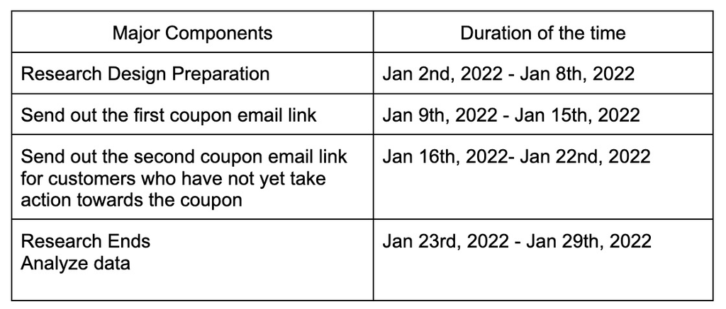

```r
knitr::include_graphics('/Users/justin4love/Desktop/Schedule.jpeg')
```

#### Data Collection

**Authors (Names and Percentages)**: Wentingm Bao (33.33%), Tianyuan Deng (33.33%), Haoyu Wang (33.33%)

#### Data Security

**Authors (Names and Percentages)**: Wentingm Bao (33.33%), Tianyuan Deng (33.33%), Haoyu Wang (33.33%)

Since the data is collected from the company’s database, there is no physical observation needed by the researchers. Without human interaction, the study can ensure that the collected data is objective and follows laws. In this research study, we only collect and use the data when customers have registered their account with us by which means that the selected participants provide this information and data voluntarily, and agree with our terms of service. Specifically, we will only collect age and gender information from the customers but not highly sensitive data, such as SSN or bank information. All the information is stored in our database and our database is fully protected by our firewall. All of our devices will be installed with up-to-date anti-virus software, operating systems will be patched with the newest version. We took precautions to ensure that there will not be any leak of our customer information: during our project, we can also ensure that files containing customer information are closed when computers will be left unattended; all the electronic data will be stored securely in password-protected computers or files. We only collect minimum data from our database to complete our research, specifically, customers’ names will be omitted and instead will be identified by computer generated ID. IP addresses will be used to ensure the uniqueness of the customer by avoiding customers registered with more than one account with us. Only the head of the analysis team will have access to the IP address. In this way our analysis team will not have access to the customer’s personal identifications so we can best protect our customer’s anonymity. During the entire program, no individual information will be used in any meetings, reports or presentations. All the participants will sign legal documents to ensure they will not disclose any customer information to third parties.

#### Outcomes (Dependent Variables)

**Authors (Names and Percentages)**: Wentingm Bao (33.33%), Tianyuan Deng (33.33%), Haoyu Wang (33.33%)

In this research, the dependent variable is if the customers make a purchase using the coupon in the treatment group and control group. The attendance performance of 400 existing customers in each group will be recorded throughout the research period. At the end of the study, the coupon usage of each customer will be recorded, and the average coupon usage rate of all the participants in each group will be calculated and compared to help determine which method will lead to a higher usage rate. The dependent variable, whether the coupon is used or not in each group, will be the outcome of this study which can reflect which coupon sending method results in a higher coupon usage rate.

#### Treatments (Independent Variables)

**Authors (Names and Percentages)**: Wentingm Bao (33.33%), Tianyuan Deng (33.33%), Haoyu Wang (33.33%)

#### Other Variables

**Authors (Names and Percentages)**: Wentingm Bao (33.33%), Tianyuan Deng (33.33%), Haoyu Wang (33.33%)

Other variables that are relevant to the results are listed with the table as shown below. Customer ID will be recorded after participants have been selected for distinguished purposes. Other acquired variables including age, gender, amount of past purchase, number of items in the past purchase and income are obtained for further examination of the relationship between the outcome.

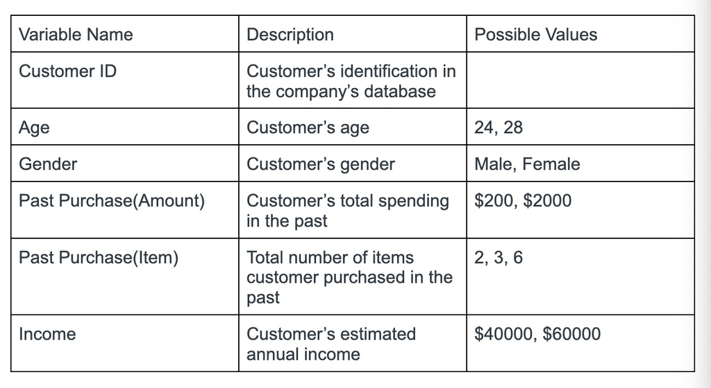

```r
knitr::include_graphics('/Users/justin4love/Desktop/Other Variable.jpeg')
```

### Statistical Analysis Plan

**Authors (Names and Percentages)**: Wentingm Bao (33.33%), Tianyuan Deng (33.33%), Haoyu Wang (33.33%)

P-value and confidence interval: For all of our tests, we will follow the convention and select 0.05 as our significant value. Correspondingly, we use a 95% confidence interval to capture the result.

Outcome explanation: If we failed to reject the null hypothesis, then the gaming methods did not make a difference in coupon usage rate. We need to investigate different approaches to increase coupon usage rate. If we reject the null hypothesis, it means using games in the coupon will result in a higher usage rate than without games in this case. The existing strategy should be generalized to all the further commercial promotions.

Missing data: To maximize the accuracy of this research and exclude possible missing data and information from participants, we only select participants who have registered an account with complete necessary information, such as age and gender. By this way, our data is subjective and complete which can avoid possible bias occurrence.

### Limitations and Uncertainties

**Authors (Names and Percentages)**: Wentingm Bao (33.33%), Tianyuan Deng (33.33%), Haoyu Wang (33.33%)

By only observing participants’ actions for this research study, we do not have the ability to interact with the participants in the two groups to ensure that they will participate in the study. Therefore, as no control towards participants action, when email has been sent to the participants, there is a possibility of missing the email. For example, the email goes to a spam or junk folder or participants may discard the email accidentally. As a result, it is possible that there are a large number of participants who did not participate due to the inability to locate the email but counted as unwilling to participate. Therefore, to reduce the possibility of this uncertainty and bias, we can only send out the same email twice for those participants who did not participate with the first link. When the study comes to the final stage, any coupon that has not been redeemed due to any reason will be marked as unused. In addition, another limitation is that participants may have two registered accounts which provides them a second chance to get coupons. To limit this confounding variable that may create bias in our results, we will monitor each participant’s IP address as mentioned previously, so that each participant only gets one coupon during the period.

## Part 2: Simulated Studies

**Authors (Names and Percentages)**: Wentingm Bao (33.33%), Tianyuan Deng (33.33%), Haoyu Wang (33.33%)

### Research Question 1:

#### Scenario 1: No Effect

**Authors (Names and Percentages)**: Wentingm Bao (33.33%), Tianyuan Deng (33.33%), Haoyu Wang (33.33%)

For scenario 1, we assumed there is no significant effect of gaming in coupon. For both control and treatment groups, 30% of the customers used the coupon with standard deviation 0.1. By simulating a single experiment, the mean for the control group is 0.2913 and the mean for the treatment group is 0.3008. We observed that there exists 0.0095 difference between two groups. From hypothesis testing, p-value is 0.1004303. The way of sending coupons has no impact on usage rate and using games in coupons lead to 0.95% increase in usage rate.

##### Simulation

```r
#One simulation
n=800
library(data.table)
library(DT)
set.seed(seed = 329)
bp.dat <- data.table(Group = c(rep.int(x = 'Treatment', times = n/2), rep.int(x = 'Control', times = n/2)))

bp.dat[Group == 'Control', BP:= round(x=rnorm(n = .N, mean = 0.3, sd = 0.1), digits = 1)]
bp.dat[Group == 'Treatment', BP:= round(x=rnorm(n = .N, mean = 0.3, sd = 0.1), digits = 1)]
datatable(data = bp.dat)
```

|  | Group | BP |
| --- | --- | --- |
| 1 | Treatment | 0.2 |
| 2 | Treatment | 0.2 |
| 3 | Treatment | 0.2 |
| 4 | Treatment | 0.4 |
| 5 | Treatment | 0.2 |
| 6 | Treatment | 0.4 |
| 7 | Treatment | 0.4 |
| 8 | Treatment | 0.4 |
| 9 | Treatment | 0.2 |
| 10 | Treatment | 0.4 |

[output cut: 790 more lines]

```r
#create function
analyze.experiment<-function(the.dat){
  require(data.table)
  setDT(the.dat)
  the.test<-t.test(x = the.dat[Group == "Treatment",  BP],
                   y = the.dat[Group == "Control", BP], alternative = "greater")
  the.effect <- the.test$estimate[1] - the.test$estimate[2]
  upper.bound <- the.test$conf.int[2]
  p <- the.test$p.value
  result <- data.table(effect = the.effect, upper_ci = upper.bound,  p = p)
  return(result)
}
analyze.experiment(the.dat = bp.dat)
```

```
   effect upper_ci         p
1: 0.0095      Inf 0.1004303
```

```r
# Find actual mean difference in two groups
library(dplyr)
bp.dat %>%
  filter(Group == "Control") %>%
  select(BP) %>%
  summary()
```

```
       BP
 Min.   :0.0000
 1st Qu.:0.2000
 Median :0.3000
 Mean   :0.2913
 3rd Qu.:0.4000
 Max.   :0.6000
```

```r
bp.dat %>%
  filter(Group == "Treatment") %>%
  select(BP) %>%
  summary()
```

```
       BP
 Min.   :0.0000
 1st Qu.:0.2000
 Median :0.3000
 Mean   :0.3008
 3rd Qu.:0.4000
 Max.   :0.6000
```

```r
#1000 simulation
B<-1000
RNGversion(vstr = 3.6)
set.seed(seed = 329 )
Experiment<-1:B
Group<-c(rep.int(x="Treatment",times=n/2),rep.int(x="Control",times=n/2))
sim.dat <-as.data.table(expand.grid(Experiment=Experiment,Group=Group))
setorderv(x=sim.dat,cols=c("Experiment","Group"),order=c(1,1))
sim.dat[Group == "Control", BP := round(x = rnorm(n = .N, mean = 0.3, sd = 0.1), digits = 2)]
sim.dat[Group == "Treatment", BP := round(x = rnorm(n = .N, mean = 0.3, sd = 0.1), digits = 2)]
dim(sim.dat)
```

```
[1] 800000      3
```

##### Analysis

```r
#analyze 1000 experiments
exp.results<-sim.dat[,analyze.experiment(the.dat=.SD),
                     keyby="Experiment"]
exp.results
```

```
      Experiment    effect upper_ci          p
   1:          1  0.005300      Inf 0.21481227
   2:          2 -0.007100      Inf 0.83572345
   3:          3 -0.007975      Inf 0.86927803
   4:          4  0.004400      Inf 0.25993221
   5:          5  0.008925      Inf 0.10519532
  ---
 996:        996  0.010725      Inf 0.06571806
 997:        997 -0.001325      Inf 0.57573494
 998:        998 -0.012375      Inf 0.95896444
 999:        999 -0.012650      Inf 0.96365362
1000:       1000  0.015700      Inf 0.01420568
```

```r
exp.results[,mean(p<0.05)]
```

```
[1] 0.051
```

```r
exp.results[,summary(effect)]
```

```
     Min.   1st Qu.    Median      Mean   3rd Qu.      Max.
-0.025525 -0.005006  0.000075 -0.000143  0.004606  0.022825
```

```r
exp.results[,summary(upper_ci)]
```

```
   Min. 1st Qu.  Median    Mean 3rd Qu.    Max.
    Inf     Inf     Inf     Inf     Inf     Inf
```

#### Scenario 2: An Expected Effect

**Authors (Names and Percentages)**: Wentingm Bao (33.33%), Tianyuan Deng (33.33%), Haoyu Wang (33.33%)

By repeating the simulation 1000 times, we achieved similar results of 0.09986 difference between two groups which also suggest that using games will result in a higher coupon usage rate.

##### Simulation

```r
set.seed(seed = 329)
bp.dat1 <- data.table(Group = c(rep.int(x = 'Treatment', times = n/2), rep.int(x = 'Control', times = n/2)))

bp.dat1[Group == 'Control', BP:= round(x=rnorm(n = .N, mean = 0.3, sd = 0.1), digits = 1)]
bp.dat1[Group == 'Treatment', BP:= round(x=rnorm(n = .N, mean = 0.4, sd = 0.1), digits = 1)]
datatable(data = bp.dat1)
```

|  | Group | BP |
| --- | --- | --- |
| 1 | Treatment | 0.3 |
| 2 | Treatment | 0.3 |
| 3 | Treatment | 0.3 |
| 4 | Treatment | 0.5 |
| 5 | Treatment | 0.3 |
| 6 | Treatment | 0.5 |
| 7 | Treatment | 0.5 |
| 8 | Treatment | 0.5 |
| 9 | Treatment | 0.3 |
| 10 | Treatment | 0.5 |

[output cut: 790 more lines]

```r
analyze.experiment(the.dat = bp.dat1)
```

```
   effect upper_ci            p
1: 0.1095      Inf 5.064809e-44
```

```r
# Find actual mean difference in two groups
library(dplyr)
bp.dat1 %>%
  filter(Group == "Control") %>%
  select(BP) %>%
  summary()
```

```
       BP
 Min.   :0.0000
 1st Qu.:0.2000
 Median :0.3000
 Mean   :0.2913
 3rd Qu.:0.4000
 Max.   :0.6000
```

```r
bp.dat1 %>%
  filter(Group == "Treatment") %>%
  select(BP) %>%
  summary()
```

```
       BP
 Min.   :0.1000
 1st Qu.:0.3000
 Median :0.4000
 Mean   :0.4007
 3rd Qu.:0.5000
 Max.   :0.7000
```

```r
B2<-1000
RNGversion(vstr = 3.6)
set.seed(seed = 329 )
Experiment<-1:B2
Group<-c(rep.int(x="Treatment",times=n/2),rep.int(x="Control",times=n/2))
sim.dat2 <-as.data.table(expand.grid(Experiment=Experiment,Group=Group))
setorderv(x=sim.dat2,cols=c("Experiment","Group"),order=c(1,1))
sim.dat2[Group == "Control", BP := round(x = rnorm(n = .N, mean = 0.3, sd = 0.1), digits = 2)]
sim.dat2[Group == "Treatment", BP := round(x = rnorm(n = .N, mean = 0.4, sd = 0.1), digits = 2)]
dim(sim.dat2)
```

```
[1] 800000      3
```

##### Analysis

```r
#analyze 1000 experiments
exp.results2<-sim.dat2[,analyze.experiment(the.dat=.SD),
                     keyby="Experiment"]
exp.results2
```

```
      Experiment   effect upper_ci            p
   1:          1 0.105300      Inf 6.664267e-49
   2:          2 0.092900      Inf 1.625634e-34
   3:          3 0.092025      Inf 2.467279e-35
   4:          4 0.104400      Inf 1.133138e-46
   5:          5 0.108925      Inf 8.093847e-47
  ---
 996:        996 0.110725      Inf 2.486611e-48
 997:        997 0.098675      Inf 2.086551e-41
 998:        998 0.087625      Inf 2.199459e-32
 999:        999 0.087350      Inf 9.845864e-33
1000:       1000 0.115700      Inf 2.018958e-51
```

```r
exp.results2[,mean(p<0.05)]
```

```
[1] 1
```

```r
exp.results2[,summary(effect)]
```

```
   Min. 1st Qu.  Median    Mean 3rd Qu.    Max.
0.07447 0.09499 0.10007 0.09986 0.10461 0.12283
```

```r
exp.results2[,summary(upper_ci)]
```

```
   Min. 1st Qu.  Median    Mean 3rd Qu.    Max.
    Inf     Inf     Inf     Inf     Inf     Inf
```

[figure not shown]

```r
knitr::include_graphics('/Users/justin4love/Desktop/Table.jpeg')
```

## References

**Authors (Names and Percentages)**: Wentingm Bao 33.33%, Tianyuan Deng 33.33%, Haoyu Wang 33.33%, Shanice Sinclair 0%, Shi Zheng NA

Foster, B. (2020, February 7). How urban outfitters is capturing the millennial market. The Smile.io Blog. Retrieved November 24, 2021, from https://blog.smile.io/urban-outfitters-is-capturing-the-millennial-market/.

Insley, V. and Nunan, D. (2014), “Gamification and the online retail experience”, International Journal of Retail & Distribution Management, Vol. 42 No. 5, pp. 340-351. https://doi.org/10.1108/IJRDM-01-2013-0030

Savignac, Emmanuelle. The Gamification of Work: The Use of Games in the Workplace. ISTE Ltd, 2016.

Team, T. (2019, April 2). What is urban outfitters’ revenue breakdown? Forbes. Retrieved November 24, 2021, from https://www.forbes.com/sites/greatspeculations/2019/04/02/what-is-urban-outfitters-revenue-breakdown/?sh=36c42ee5365e.

Xi, Nannan, and Juho Hamari. “The Relationship between Gamification, Brand Engagement and Brand Equity.” Proceedings of the 52nd Hawaii International Conference on System Sciences, 2019, https://doi.org/10.24251/hicss.2019.099.

Reibstein, D. J. (1982). Factors affecting coupon redemption rates. Journal of Marketing (Pre-1986), 46(000004), 102. Retrieved from https://login.ezproxy.library.tufts.edu/login?url=https://www.proquest.com/scholarly-journals/factors-affecting-coupon-redemption-rates/docview/209266133/se-2?accountid=14434

Reimers, I., & Xie, C. C. (2019). Do coupons expand or cannibalize revenue? evidence from an E-market. Management Science, 65(1), 286-300. Retrieved from https://login.ezproxy.library.tufts.edu/login?url=https://www.proquest.com/scholarly-journals/do-coupons-expand-cannibalize-revenue-evidence-e/docview/2372779860/se-2?accountid=14434

Nevo, A., & Wolfram, C. (2002). Why do manufacturers issue coupons? an empirical analysis of breakfast cereals. The Rand Journal of Economics, 33(2), 319-339. Retrieved from https://login.ezproxy.library.tufts.edu/login?url=https://www.proquest.com/scholarly-journals/why-do-manufacturers-issue-coupons-empirical/docview/236535890/se-2?accountid=14434